# Effects of time and demographic factors on the use of the Ford Gobike bike share service.

## by Sheila Alwanga Olayo

## Investigation Overview

> For the presentation, I focus on time and demographic information and how they affect the numbers of bike rides. First, I introduce each of the features independently, showing their distributions and frequencies starting with **ride duration**, **period of day**, **day of the week**, **gender** then **age** in that order.

> Afterwards, I show how combinations of these features affect the numbers of bike rides with respect to each other. By first plotting **ride duration** against **period of day**, **day of the week** then **gender**. Then plotting **period of day** against **day**.

## Dataset Overview

> The dataset includes information about individual rides made in a bike sharing system covering the greater San Francisco Bay area, for the month of February, 2019.

> My dataset initially had 183,412 records and 16 columns. However after some wrangling which involved dropping records with null or inaccurate values and some feature engineering, the dataset now has 174,877 records and 21 columns. The five additional columns include **'date', 'day', 'day_period'** derived from the **'start_time'** column, **'age'** derived from **'member_birth_year'** column and **'duration_min'** derived from the **'duration_sec'** column.

### Distribution of the length of bike rides

Due to the wide range of values for the length of bike rides, this plot focuses on the 0-80 minute range, where the larger majority of data is concentrated. The distribution is right skewed, with a steep rise in the 5-10 minute range where majority of the values lie, and an equally steep decline in the 10-15 minute range as frequencies go on decreasing. Majority of rides are therefore 5-10 minutes long.

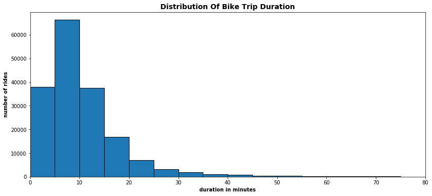

### Frequency of rides as per period of the day

The period of the day with the highest number of bike rides is the evening, that is between 4 pm and 11 pm. Followed closely by the morning period, 6am - 11:59 am. The late night period 12am - 5:59pm however has a very low frequency of bike rides.

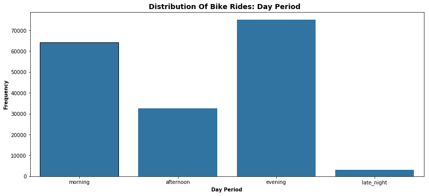

### Frequency of rides as pertaining to the day of the week

The plot shows that Thursdays tend to have the most number of rides,closely followed by Tuesdays, while Saturdays and Sundays register the least number rides.

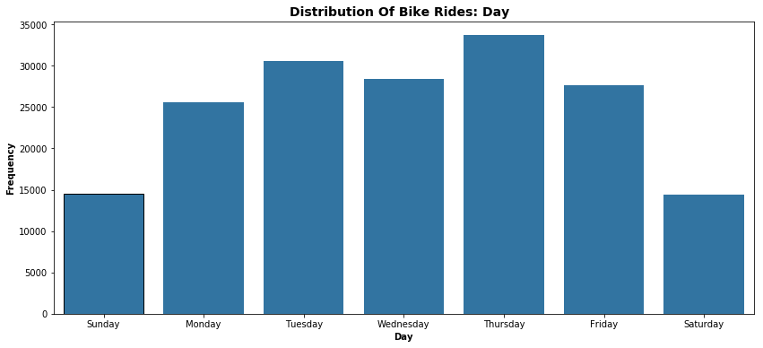

### Distribution of the frequency of rides according to gender

A majority of rides are taken by male members, with the number of rides by female members equating to approximately a third of that of male members.

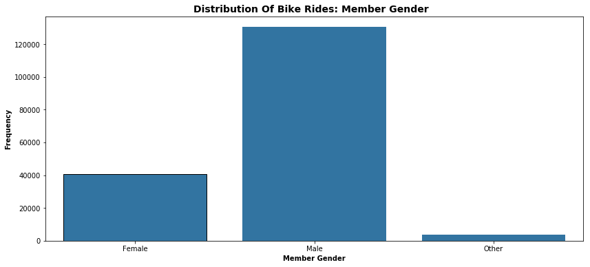

### Distribution of frequency of rides for different age groups

This is a slightly right skewed distribution with a majority number of the rides lying in the mid 20's to early 30's age group. There's a sharp drop in the number of rides at the age 40 mark and this drop continuously tapers off, declining as the ages increase up until the 90's.

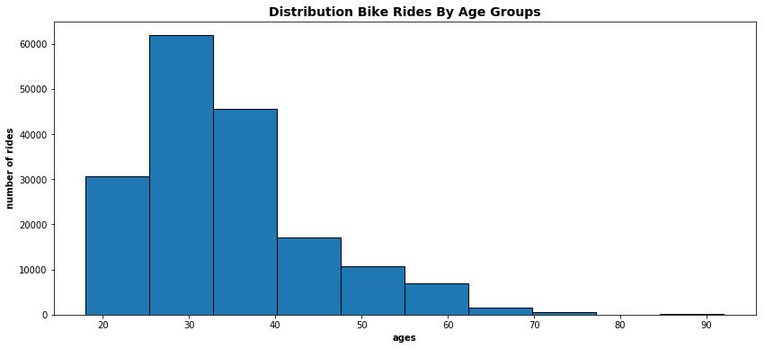

### Ride duration by period of the day

The distribution of the ride duration values throughout all the periods of the day, except the late night still shows the 5-10 minute rides being a majority. Minor differences are however seen for other time ranges. In the mornings, there are more 10-15 minute rides as opposed to 0-5 minute rides. The opposite is however true for the afternoon and evening. The late night period is an exception to all this because it appears to have an equal number of rides that are in the 0-5 and 5-10 minute ranges, these being the majority.

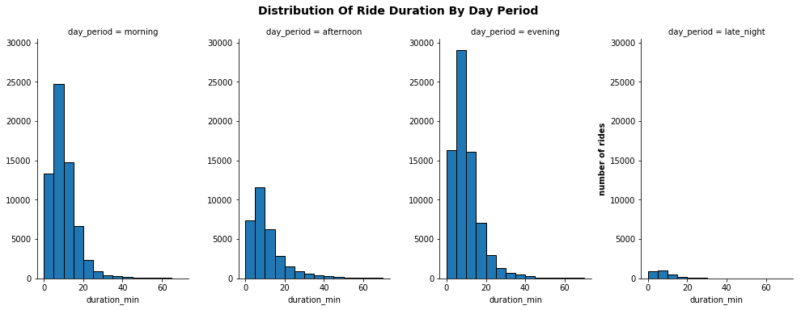

### Ride duration by day of the week

The distribution of the ride duration values against days of the week also still shows that 5-10 minute bike rides were the majority across all the days of the week. The variations here also appear in the differences betweeen 0-5 minute and 10-15 minute ranges. On Sundays,Mondays and Saturdays, the number of 0-5 minute bike rides are slightly higher, while on Tuesdays and Thursdays the 10-15 minute bike rides are slightly more. Note that Tuesdays and Thursdays overall have the highest number of bike rides throughout the week. Perhaps they are the busier days, hence why people are taking longer bike rides to supplement regular transport means.

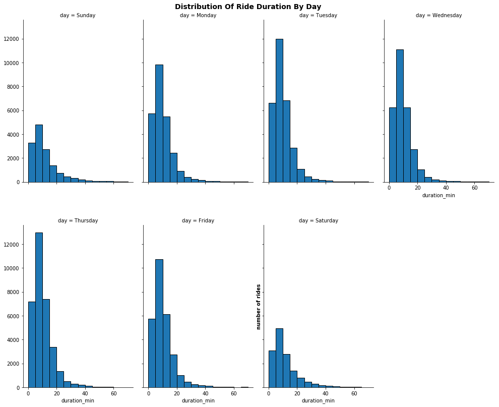

### Ride duration by gender

The 5-10 minute ride duration still has the highest frequency across all genders. However, there are more 10-15 minute rides relative to 0-5 minute rides by female members while the opposite is true for male members.

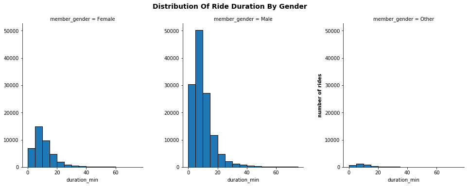

### Bike rides by day and day periods

On the week-days, mornings and evenings are seen to have the higher numbers of bike rides. While on the weekends, afternoons and evenings have the higher numbers with each of their counts being nearly equal. Although evenings have been seen to have the highest number of bike rides generally, Friday evenings have a lower number of rides compared to Friday mornings.

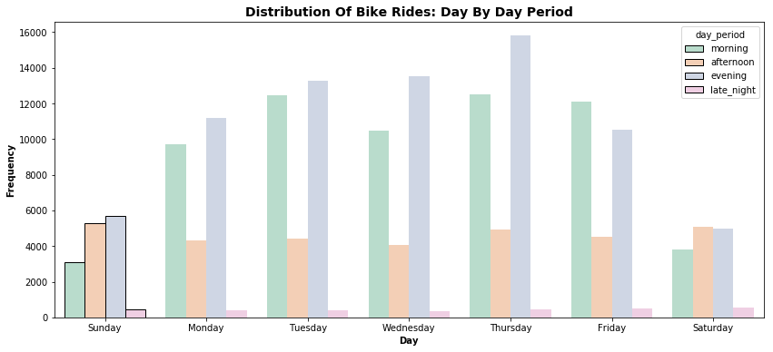

### Summary

> The features of interest were observed to be largely independent with only slight variations when plotted against each other and in other instances, no variations at all. They each affect the number of bike rides to varying degrees, with some such as gender, age, ride duration, period of the day having a stronger effect than others like what day of the week it is.